# Explanation of the Objective Functions

Daniel Klotz, Johannes Wesemann, Mathew Herrnegger

08 August 2016

# 1 Introduction

This chapter defines the objective functions $of$ that are used in **visCOS** The code for exploring and visualising objective function is defined in separate sections:

- Explore Basin-Graphs with objective functions
- Explore periodical objective functions

Currently 4 objective functions are used in **visCOS**. They are calculated from the data columns of a data.frame defined by `viscos_options("name_o")` and `viscos_options("name_s")`. Assuming that `name_o` is $x$ and `name_o` is $y$ they are defined as shown in the following.

## 1.1 Nash-Sutcliffe Efficiency

The variable $\bar{x}$ represents the average of $x$. The $NSE$ can therefore be seen as the relational the estimator $y$ and the estimator resulting form the average of the data. It can can have values between minus infinity and 1 with 1 being the perfect fit, 0 when the mean of $y$ is as good as the mean of $x$ and negative values are even worse. The following figures illustrate different $NSE$ values for naive examples.

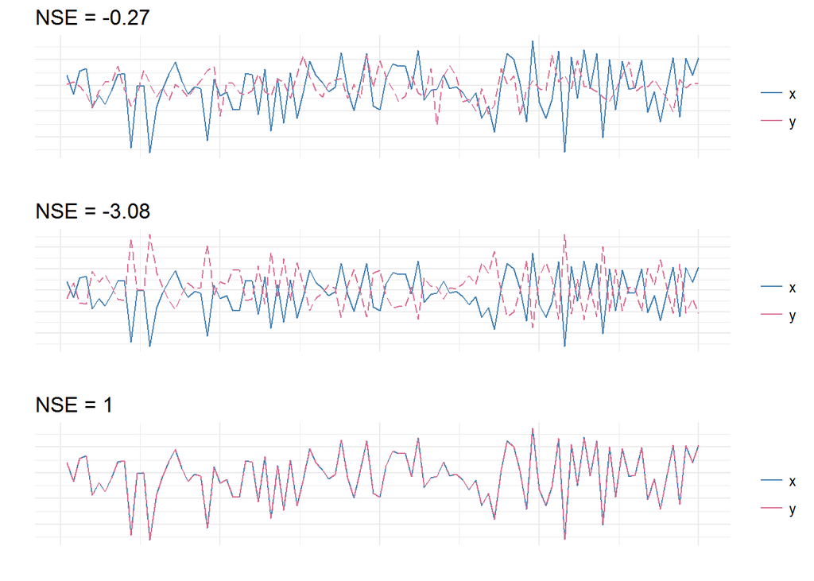

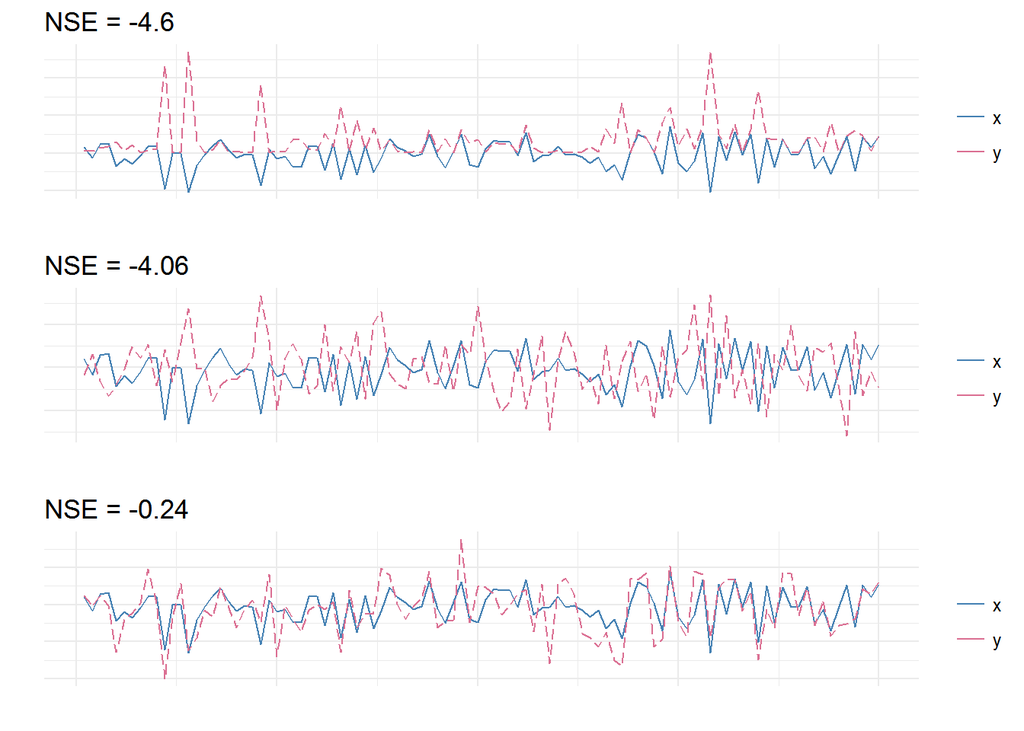

## 1.2 Kling-Gupta Efficiency

The Kling-Gupta Efficiency $KGE$ was introduced by Gupta et al. (2009) to alleviate some of the shortcomings of the $NSE$. In their paper they argue why the $NSE$ tends to overate simulations with small variance (note: in the context of the paper $\textrm{simulations} = y$) and propose their efficiency criterion instead.

The $KGE$ is defined as:

$$KGE = 1 - ED,$$

with

$$ED = \sqrt{ (corr-1)^2 + (\alpha-1)^2 + (\beta-1)^2) };$$

Where $\alpha = \frac{\sigma_y}{ \sigma_x }$ is the standard deviation $\sigma$ of $y$ divided by the $\sigma$ of $x$, $\beta = \mu_y / \mu_x$ with $\mu$ being the arithmetic mean and $corr$ as the Pearson’s correlation coefficient (see chapter 1.4).

The value range and the quality is similar to the $NSE$. The following figures exemplify its usage for the same data as above.

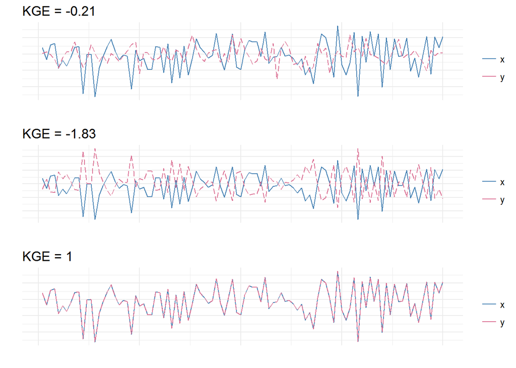

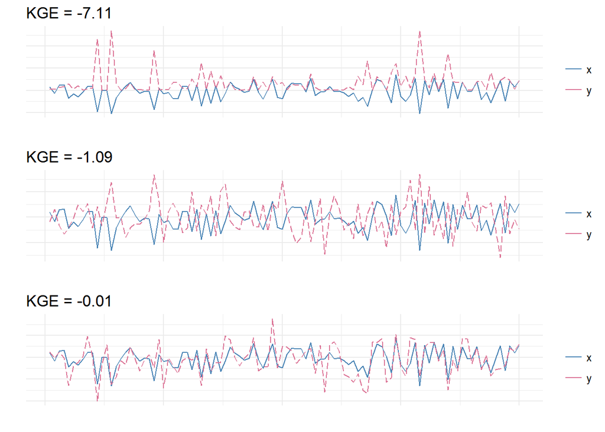

## 1.3 Percentage Bias

The percentage of bias $p_{bias}$ is defined as the sum of the differences between $x$ and $y$ divided by the sum of $x$:

$$p_{bias} = 100*\frac{\sum_{} [ x(t)-y(t) ] }{\sum_{} x(t)}.$$

The $100*$ is just a scaling factor applied to express $p_{bias}$ as a percentage. The following figure illustrates different $p_{bias}$ values for the same data as above.

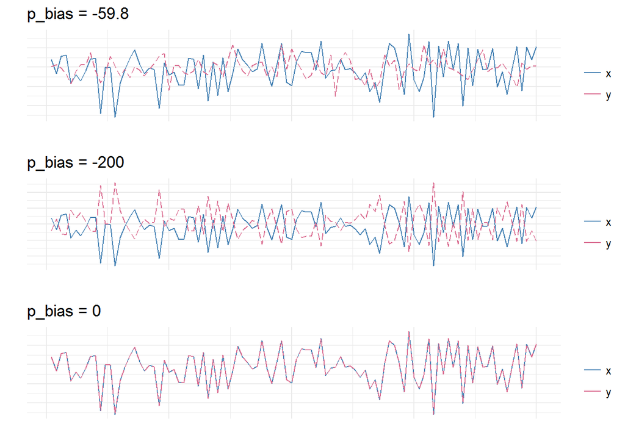

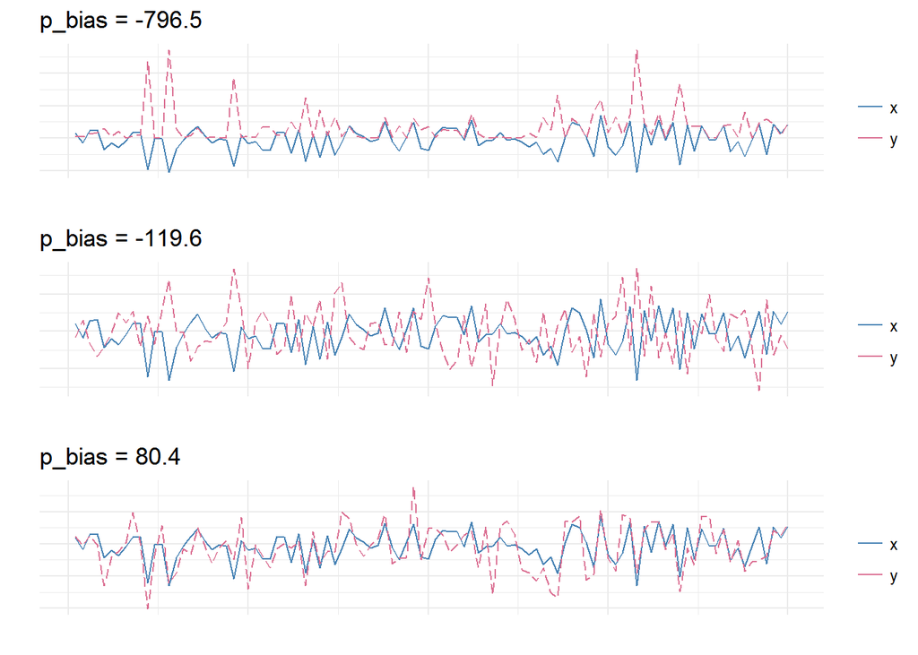

## 1.4 Pearson’s correlation coefficient

The correlation coefficient $corr$ is a measure of the linear relationship between $x$ and $y$. It is defined as:

$$r \equiv corr = \frac{cov(x,y)}{\sigma_y*\sigma_x},$$

where $cov(...)$ denotes the covariance and $\sigma^2$ the variance. The correlation coefficient can take on values between -1 and 1. The former corresponds to an inverse and the latter to a direct relationship and the closer the values is to zero the weaker is the implied correlation. The following figures display the $corr$ for the previously used data:

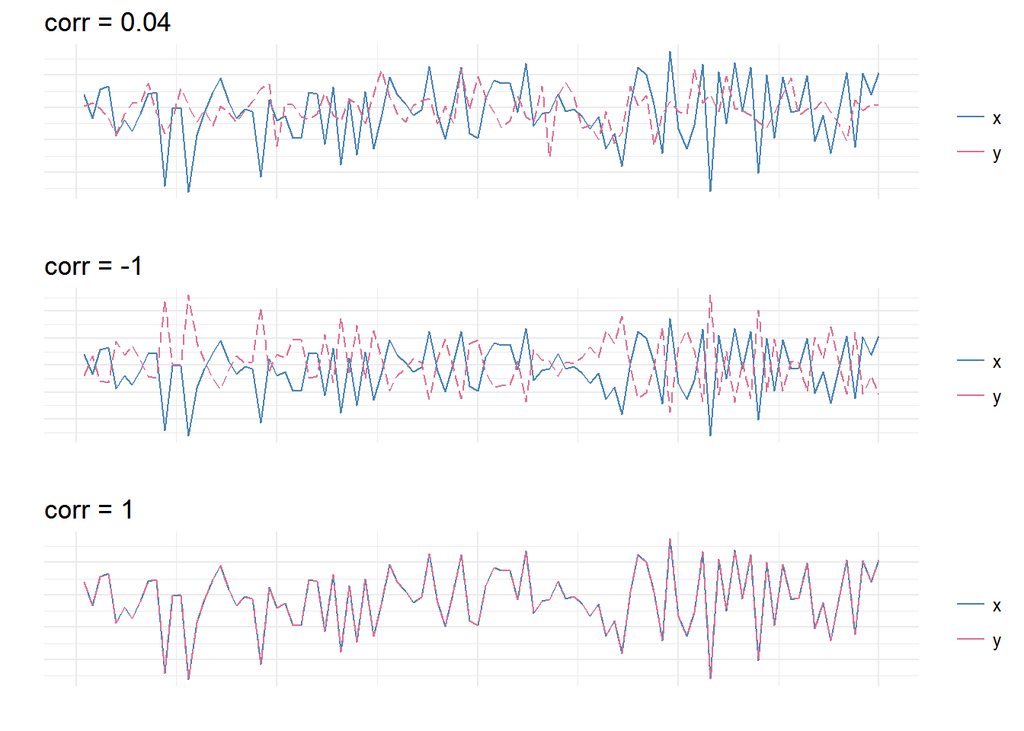

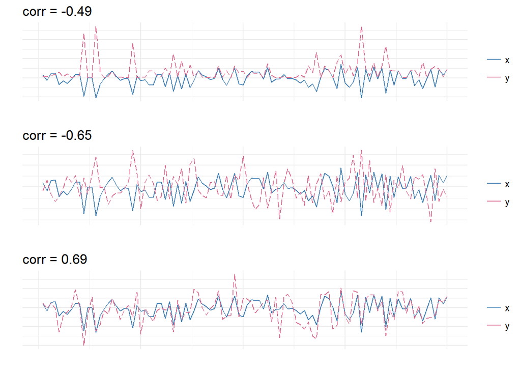

To get a better understanding of the data and the correlation in special it can be usefull to plot the data in a scatter plot with $x$ as the abscissa and $y$ as the ordinate:

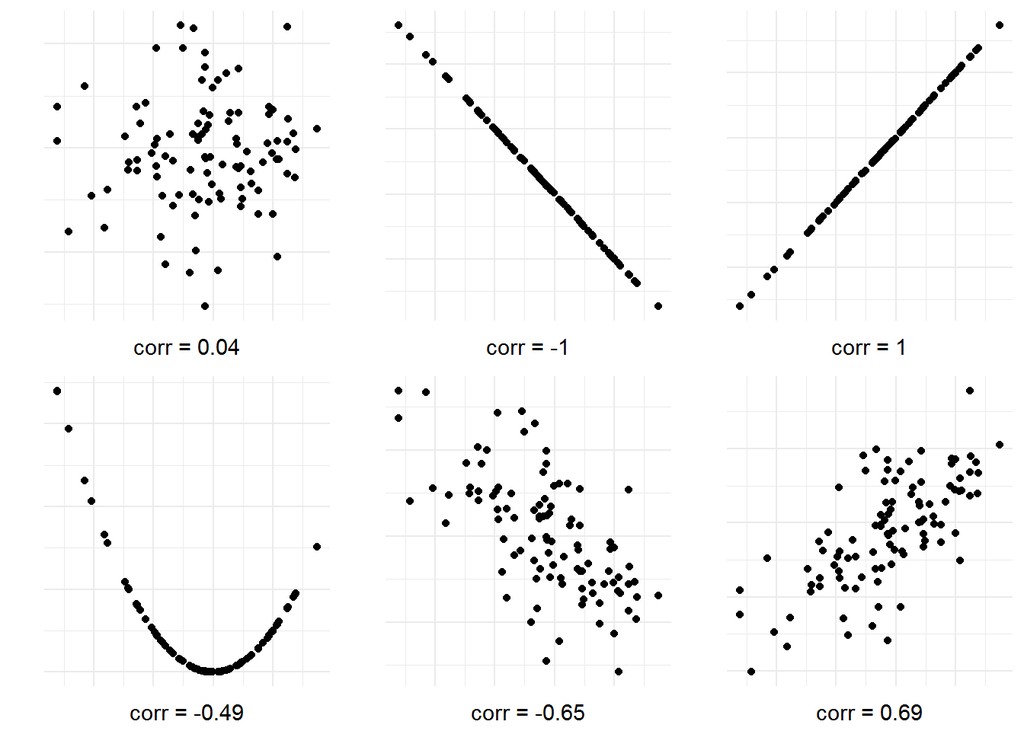